# project_analysis

RawanGalal

3/11/2021

```r
library(tidyverse)
library(stringr)
library(lubridate)
```

```r
library(ggplot2)
library(janitor)
library(plotly)
data = read_csv("Data.csv")
data
```

```
## # A tibble: 119,390 x 32
##    hotel is_canceled lead_time arrival_date_ye~ arrival_date_mo~
##    <chr>       <dbl>     <dbl>            <dbl> <chr>
##  1 Reso~           0       342             2015 July
##  2 Reso~           0       737             2015 July
##  3 Reso~           0         7             2015 July
##  4 Reso~           0        13             2015 July
##  5 Reso~           0        14             2015 July
##  6 Reso~           0        14             2015 July
##  7 Reso~           0         0             2015 July
##  8 Reso~           0         9             2015 July
##  9 Reso~           1        85             2015 July
## 10 Reso~           1        75             2015 July
## # ... with 119,380 more rows, and 27 more variables:
## #   arrival_date_week_number <dbl>, arrival_date_day_of_month <dbl>,
## #   stays_in_weekend_nights <dbl>, stays_in_week_nights <dbl>, adults <dbl>,
## #   children <dbl>, babies <dbl>, meal <chr>, country <chr>,
## #   market_segment <chr>, distribution_channel <chr>, is_repeated_guest <dbl>,
## #   previous_cancellations <dbl>, previous_bookings_not_canceled <dbl>,
## #   reserved_room_type <chr>, assigned_room_type <chr>, booking_changes <dbl>,
## #   deposit_type <chr>, agent <chr>, company <chr>, days_in_waiting_list <dbl>,
## #   customer_type <chr>, adr <dbl>, required_car_parking_spaces <dbl>,
## #   total_of_special_requests <dbl>, reservation_status <chr>,
## #   reservation_status_date <date>
```

```r
data_city <- data %>% filter(hotel== "City Hotel")
data_resort <- data %>% filter(hotel == "Resort Hotel")
tabyl(data_city$arrival_date_month)
```

```
##  data_city$arrival_date_month    n    percent
##                         April 7480 0.09428968
##                        August 8983 0.11323585
##                      December 4132 0.05208622
##                      February 4965 0.06258666
##                       January 3736 0.04709442
##                          July 8088 0.10195386
##                          June 7894 0.09950838
##                         March 6458 0.08140678
##                           May 8232 0.10376907
##                      November 4357 0.05492248
##                       October 7605 0.09586537
##                     September 7400 0.09328123
```

```r
tabyl(data_resort$arrival_date_month)
```

```
##  data_resort$arrival_date_month    n    percent
##                           April 3609 0.09008987
##                          August 4894 0.12216675
##                        December 2648 0.06610085
##                        February 3103 0.07745881
##                         January 2193 0.05474289
##                            July 4573 0.11415377
##                            June 3045 0.07601098
##                           March 3336 0.08327509
##                             May 3559 0.08884174
##                        November 2437 0.06083375
##                         October 3555 0.08874189
##                       September 3108 0.07758362
```

```r
#data_resort
```

# Q1: is there a certain market segment that increases no. of transactions?

```r
data_resort %>% tabyl(market_segment)
```

```
##  market_segment     n     percent
##   Complementary   201 0.005017474
##       Corporate  2309 0.057638542
##          Direct  6513 0.162581128
##          Groups  5836 0.145681478
##   Offline TA/TO  7472 0.186520220
##       Online TA 17729 0.442561158
```

## Understanding market segments in hotels:

### 2. Corporate – These are the guests that stay at the hotel at discounted company rates. The discounted rates are available on a contract basis to corporate clients who bring in frequent business.

### 3. Direct –This segment consists of direct bookings with the hotel done over phone calls or emails.

### 5. Online TA: online third-party travel agencies that allow people to make reservations for various hotels through their platform. For example, Trivago, TripAdvisor,

### 44% of market segment in resort hotels are online TA, while only .5% are complementary

### insight: maintain the online TA>> turn them into loyal customers, and work on increasing the comp. cusstomers

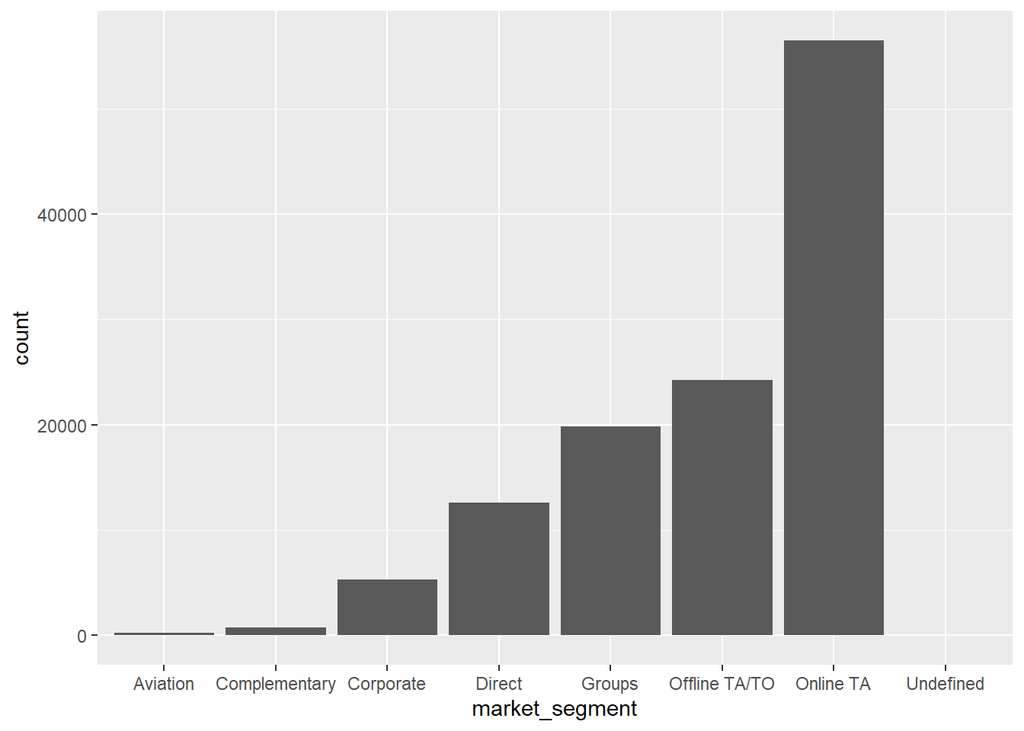

```r
g <- ggplot(data, aes(market_segment))
g + geom_bar()
```

```r
data
```

```
## # A tibble: 119,390 x 32
##    hotel is_canceled lead_time arrival_date_ye~ arrival_date_mo~
##    <chr>       <dbl>     <dbl>            <dbl> <chr>
##  1 Reso~           0       342             2015 July
##  2 Reso~           0       737             2015 July
##  3 Reso~           0         7             2015 July
##  4 Reso~           0        13             2015 July
##  5 Reso~           0        14             2015 July
##  6 Reso~           0        14             2015 July
##  7 Reso~           0         0             2015 July
##  8 Reso~           0         9             2015 July
##  9 Reso~           1        85             2015 July
## 10 Reso~           1        75             2015 July
## # ... with 119,380 more rows, and 27 more variables:
## #   arrival_date_week_number <dbl>, arrival_date_day_of_month <dbl>,
## #   stays_in_weekend_nights <dbl>, stays_in_week_nights <dbl>, adults <dbl>,
## #   children <dbl>, babies <dbl>, meal <chr>, country <chr>,
## #   market_segment <chr>, distribution_channel <chr>, is_repeated_guest <dbl>,
## #   previous_cancellations <dbl>, previous_bookings_not_canceled <dbl>,
## #   reserved_room_type <chr>, assigned_room_type <chr>, booking_changes <dbl>,
## #   deposit_type <chr>, agent <chr>, company <chr>, days_in_waiting_list <dbl>,
## #   customer_type <chr>, adr <dbl>, required_car_parking_spaces <dbl>,
## #   total_of_special_requests <dbl>, reservation_status <chr>,
## #   reservation_status_date <date>
```

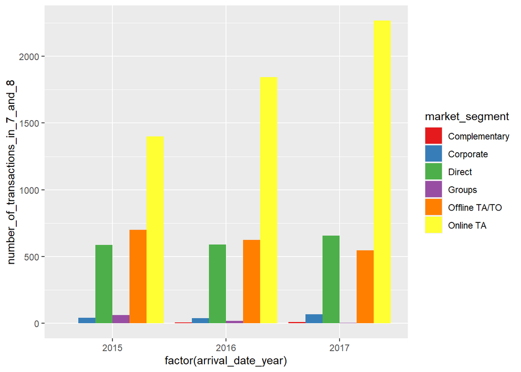

```r
#tabyl(data_resort$arrival_date_month)
# cond: market segment
#value: trxs
# x: year buckets
 data_resort %>% filter(arrival_date_month == "July" | arrival_date_month == "August") %>%
 group_by(arrival_date_year, market_segment) %>%
 summarise(number_of_transactions_in_7_and_8 = n() , market_segment = market_segment) %>%
 ggplot( aes(factor(arrival_date_year), number_of_transactions_in_7_and_8 , fill = market_segment)) +
 geom_bar(stat="identity", position = "dodge") +
 scale_fill_brewer(palette = "Set1")
```

#### *insights* : 1. Online TA reached is increasing over years in peak months > recommendations: maintain their loyalty > points, discounts, through TA …